# homework-number-5

```r
library(curl)
library(knitr)
library(boot)
```

```r
f <- curl("https://raw.githubusercontent.com/fuzzyatelin/fuzzyatelin.github.io/master/AN597_Fall17/KamilarAndCooperData.csv")
d <- read.csv(f, header = TRUE, sep = ",", stringsAsFactors = FALSE)
head(d)
```

```
##               Scientific_Name          Family          Genus      Species
## 1 Allenopithecus_nigroviridis Cercopithecidae Allenopithecus nigroviridis
## 2         Allocebus_trichotis Cercopithecidae      Allocebus    trichotis
## 3           Alouatta_belzebul        Atelidae       Alouatta     belzebul
## 4             Alouatta_caraya        Atelidae       Alouatta       caraya
## 5            Alouatta_guariba        Atelidae       Alouatta      guariba
## 6           Alouatta_palliata        Atelidae       Alouatta     palliata
##   Brain_Size_Species_Mean Brain_Size_Female_Mean   Brain_size_Ref
## 1                   58.02                  53.70 Isler et al 2008
## 2                      NA                     NA
## 3                   52.84                  51.19 Isler et al 2008
## 4                   52.63                  47.80 Isler et al 2008
## 5                   51.70                  49.08 Isler et al 2008
## 6                   49.88                  48.04 Isler et al 2008
##   Body_mass_male_mean Body_mass_female_mean Mass_Dimorphism
```

[output cut: 69 more lines]

# 1

```r
h <- log(d$HomeRange_km2)

b <- log(d$Body_mass_female_mean)
```

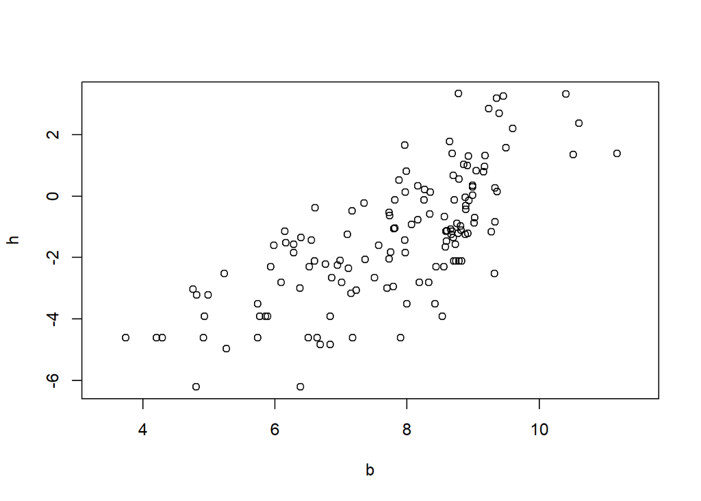

```r
plot(x = b, y = h)
```

Here I plotted log(HomeRange_km2) and log(Body_mass_female_mean) so see if there is a visual the relation

```r
m <- lm(data = d, h ~ b)
summary(m)
```

```
##
## Call:
## lm(formula = h ~ b, data = d)
##
## Residuals:
##     Min      1Q  Median      3Q     Max
## -3.3929 -0.9433 -0.0126  1.0944  3.6826
##
## Coefficients:
##             Estimate Std. Error t value Pr(>|t|)
## (Intercept) -9.44123    0.67293  -14.03   <2e-16 ***
## b            1.03643    0.08488   12.21   <2e-16 ***
## ---
## Signif. codes:  0 '***' 0.001 '**' 0.01 '*' 0.05 '.' 0.1 ' ' 1
##
## Residual standard error: 1.423 on 135 degrees of freedom
##   (76 observations deleted due to missingness)
## Multiple R-squared:  0.5248, Adjusted R-squared:  0.5213
## F-statistic: 149.1 on 1 and 135 DF,  p-value: < 2.2e-16
```

Here the intercept is -9.44123 and the slope is 1.03643, the standard error for the intercept is 0.67293, the standard errror for the slope is 0.08488

```r
confint(m, level = 0.95)
```

```
##                   2.5 %    97.5 %
## (Intercept) -10.7720889 -8.110374
## b             0.8685707  1.204292
```

here are the confidence intervales for the intercept is -10.7720889 to -8.110374, and the CI for slope is 0.8685707 to 1.204292